# Observational Study

Regular Assignment Mechanism

Last Update: 2024-03-05

Here, we implement methods in the observational study with regular assignment mechanism. We consider the following methods: imputing by a linear regression, using a weighing estimator, using a blocking estimator, and using a matching estimator.

# 1 Generating simulation data

## 1.1 Setting constants and parameters

First, we set the seed and the number of observations `N`, blocks for the blocking estimator `J`, and neighbors for the matching estimator `M`. We also set the true coefficients.

```r
set.seed(1)
N <- 1000
J <- 4
M <- 1
beta_t <- c(1, 0.1)
beta_c <- c(0, 0.05)
```

## 1.2 Generating data

We generate the data for the observational study. We generate the covariate `x` from a standard normal distribution and the potential outcomes `y_0` and `y_1` from normal distributions with the true coefficients.

```r
outcome <-
  tibble::tibble(
    x = rnorm(N),
    y_0 = beta_c[1] + beta_c[2] * x + rnorm(N),
    y_1 = beta_t[1] + beta_t[2] * x + rnorm(N)
  )
head(outcome)
```

| x | y_0 | y_1 |
| --- | --- | --- |
| -0.6264538 | 1.10364240 | 0.05120503 |
| 0.1836433 | 1.12111401 | -0.90389056 |
| -0.8356286 | -0.91255906 | 2.53613788 |
| 1.5952808 | 0.29049563 | 1.67879798 |
| 0.3295078 | 0.08587104 | 0.97710085 |
| -0.8204684 | -1.70367227 | 1.61437077 |

We calculate the average treatment effect in the sample.

```r
tau_fs <-
  outcome %>%
  dplyr::summarise(tau = mean(y_1 - y_0)) %>%
  dplyr::pull(tau)
tau_fs
```

```
## [1] 1.030989
```

We calculate the propensity score and assign the treatment based on the propensity score. Thus, the assignment mechanisms depends on the covariates.

```r
outcome <-
  outcome %>%
  dplyr::mutate(
    e = exp(x) / (1 + exp(x)),
    z = (runif(N) < e)
    )
head(outcome)
```

| x | y_0 | y_1 | e | z |
| --- | --- | --- | --- | --- |
| -0.6264538 | 1.10364240 | 0.05120503 | 0.3483151 | FALSE |
| 0.1836433 | 1.12111401 | -0.90389056 | 0.5457822 | FALSE |
| -0.8356286 | -0.91255906 | 2.53613788 | 0.3024562 | FALSE |
| 1.5952808 | 0.29049563 | 1.67879798 | 0.8313578 | TRUE |
| 0.3295078 | 0.08587104 | 0.97710085 | 0.5816396 | FALSE |
| -0.8204684 | -1.70367227 | 1.61437077 | 0.3056642 | TRUE |

## 1.3 Check the balance in the covariate

We check the balance in the covariate `x` between the treatment and control groups.

[figure not shown]

```r
outcome_observed <-
  outcome %>%
  dplyr::mutate(y = y_0 * (1 - z) + y_1 * z) %>%
  dplyr::select(y, z, x)
head(outcome_observed)
```

| y | z | x |
| --- | --- | --- |
| 1.10364240 | FALSE | -0.6264538 |
| 1.12111401 | FALSE | 0.1836433 |
| -0.91255906 | FALSE | -0.8356286 |
| 1.67879798 | TRUE | 1.5952808 |
| 0.08587104 | FALSE | 0.3295078 |
| 1.61437077 | TRUE | -0.8204684 |

# 2 Analysis

## 2.1 Imputing by a linear regression

We estimate the average treatment effect by imputing the potential outcomes by a linear regression.

```r
result <-
  lm(
    data = outcome_observed,
    formula = y ~ x * z
  )
result %>%
  modelsummary(fmt = 6)
```

|  | (1) |
| --- | --- |
| (Intercept) | −0.017528 |
|  | (0.049717) |
| x | 0.088752 |
|  | (0.047710) |
| zTRUE | 1.103605 |
|  | (0.073258) |
| x × zTRUE | −0.020311 |
|  | (0.070905) |
| Num.Obs. | 1000 |
| R2 | 0.238 |
| R2 Adj. | 0.236 |
| AIC | 2949.7 |
| BIC | 2974.3 |
| Log.Lik. | −1469.856 |
| F | 103.888 |
| RMSE | 1.05 |

```r
outcome_counterfactual <-
  outcome_observed %>%
  dplyr::mutate(
    z = 1 - z,
    z = z %>% as.logical()
  ) %>%
  dplyr::mutate(
    y = predict(result, newdata = .)
  )
outcome <-
  rbind(
    outcome_observed,
    outcome_counterfactual
  )
outcome <-
  outcome %>%
  dplyr::group_by(z) %>%
  dplyr::summarize(y = mean(y)) %>%
  dplyr::ungroup()
outcome %>% dplyr::filter(z) - outcome %>%dplyr::filter(!z)
```

| z | y |
| --- | --- |
| 1 | 1.103842 |

## 2.2 Using a weighing estimator

We first estimate the propensity score by a correctly specified logistic function.

```r
propensity_score <-
  glm(
    data = outcome_observed,
    formula = z ~ x,
    family = binomial("logit")
  )
propensity_score %>%
  modelsummary(fmt = 6)
```

|  | (1) |
| --- | --- |
| (Intercept) | −0.139605 |
|  | (0.069562) |
| x | 0.951090 |
|  | (0.080246) |
| Num.Obs. | 1000 |
| AIC | 1204.7 |
| BIC | 1214.5 |
| Log.Lik. | −600.337 |
| F | 140.473 |
| RMSE | 0.45 |

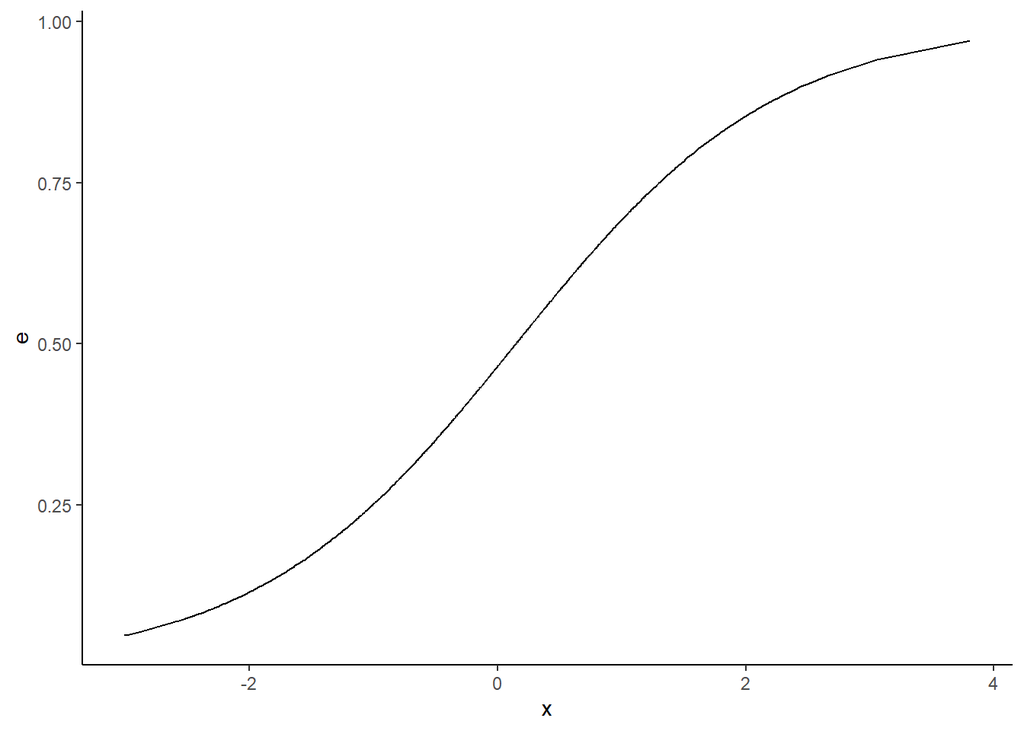

```r
outcome_observed <-
  outcome_observed %>%
  dplyr::mutate(e = predict(propensity_score, type = "response"))
outcome_observed %>%
  ggplot(
    aes(
      x = x,
      y = e
    )
  ) +
  geom_line() +
  theme_classic()
```

```r
outcome_observed %>%
  dplyr::mutate(weight = (z / e + (1 - z) / (1 - e)) / length(z)) %>%
  dplyr::summarise(y = sum(z * y * weight) - sum((1 - z) * y * weight))
```

| y |
| --- |
| 1.083165 |

## 2.3 Using a blocking estimator

```r
blocking_estimator <-
  outcome_observed %>%
  dplyr::mutate(j = dplyr::ntile(outcome_observed$e, J)) %>%
  dplyr::group_by(j) %>%
  dplyr::summarise(
    N_j = length(y),
    y = sum(y * z) / sum(z) - sum(y * (1 - z)) / sum(1 - z)
    ) %>%
  dplyr::ungroup()
blocking_estimator
```

| j | N_j | y |
| --- | --- | --- |
| 1 | 250 | 1.087479 |
| 2 | 250 | 1.211927 |
| 3 | 250 | 1.002900 |
| 4 | 250 | 1.166894 |

```r
blocking_estimator %>%
  dplyr::summarise(y = sum(y * N_j) / sum(N_j))
```

| y |
| --- |
| 1.1173 |

## 2.4 Using a matching estimator

```r
matched <-
  MatchIt::matchit(
    data = outcome_observed,
    formula = z ~ x,
    method = "nearest",
    distance = "glm",
    ratio = M
  )
 matched
```

```
## A matchit object
##  - method: 1:1 nearest neighbor matching without replacement
##  - distance: Propensity score
##              - estimated with logistic regression
##  - number of obs.: 1000 (original), 938 (matched)
##  - target estimand: ATT
##  - covariates: x
```

```r
matched_observed <-
  MatchIt::match.data(matched)
matched_observed
```

| y | z | x | e | distance | weights | subclass |
| --- | --- | --- | --- | --- | --- | --- |
| 1.103642398 | FALSE | -0.626453811 | 0.32400671 | 0.32400671 | 1 | 424 |
| 1.121114011 | FALSE | 0.183643324 | 0.50876329 | 0.50876329 | 1 | 59 |
| -0.912559064 | FALSE | -0.835628612 | 0.28204038 | 0.28204038 | 1 | 363 |
| 1.678797985 | TRUE | 1.595280802 | 0.79861359 | 0.79861359 | 1 | 158 |
| 0.085871036 | FALSE | 0.329507772 | 0.54333774 | 0.54333774 | 1 | 39 |
| 1.614370772 | TRUE | -0.820468384 | 0.28496924 | 0.28496924 | 1 | 265 |
| 1.102258584 | TRUE | 0.487429052 | 0.58029499 | 0.58029499 | 1 | 314 |
| -0.236451027 | TRUE | 0.738324705 | 0.63705598 | 0.63705598 | 1 | 366 |
| -1.065487923 | TRUE | 0.575781352 | 0.60061193 | 0.60061193 | 1 | 412 |
| 0.982885026 | FALSE | -0.305388387 | 0.39411280 | 0.39411280 | 1 | 113 |

[output cut: 928 more lines]

```r
matched_observed %>%
  dplyr::group_by(subclass) %>%
  dplyr::summarise(y = sum(y * z) - sum(y * (1 - z))) %>%
  dplyr::ungroup() %>%
  dplyr::summarise(y = mean(y))
```

| y |
| --- |
| 1.145497 |